# taiwan_baselines

Ribas-Deulofeu L. et al. 2026

2026-05-14

### Generate R Script

```r
knitr::purl("taiwan_baselines.Rmd", documentation = 0)
```

### Packages

```r
### Packages
# Data formatting
library(tidyverse)
library(dplyr)

# Visualisation
library(ggpubr)
library(viridis)
library(ggplot2)
library(yarrr)
library(multcompView)
library(terra)
library(sf)

# Statistical analyses
library(vegan)
library(labdsv)
library(dunn.test)
library(RVAideMemoire)
library(mgcv)
library(coin)
```

**Note**: All figures were produced in R (version 4.2.0). Final figure aesthetics and panel arrangements were adjusted in Inkscape (version 1.3.2) for publication formatting purposes. All data representations remain unaltered.

### Dataset

1. Import and format data

```r
### Dataset - Benthic composition and environmental data at study locations ###

# Benthic composition (morpho-functional group) with environmental data at study location (for GAMs)
BenthicMorphoFunctwithEnvVar<-read.csv("Data/Dataset - Benthic composition (morpho-funct. group-mean) and env. parameters at survey locations (2016-2023).csv", header = T, row.names = "Location")

# Subset without env. parameters for benthic analysis
#1. Morpho-functional group level
BenthicMorphoFunctnoEnvVar<-BenthicMorphoFunctwithEnvVar%>% select(-c(Site, Depth, Site_Depth_Date, Region, latitude, longitude, max.monthly.SST, min.monthly.SST, PAR))

#2. Major category level
BenthicMAjCat<-read.csv("Data/Dataset - Benthic composition (major cat.-mean) at survey locations (2016-2023).csv",header=T,row.names= "Site_Depth_Date")
```

2. Import factors (Region, MPA protection level, Morpho-functional group)

```r
### Factors - Study location and MPA protection level ###
LocationFactor<- read.csv("Data/Factor - Location Level.csv", header=T)

# Study site vector for mapping
StudySite<-LocationFactor[,c(4:5,9:11)]
StudySiteVector<- vect(StudySite, geom=c("longitude", "latitude"), crs="+proj=longlat +datum=WGS84",keepgeom=T)

# Define the custom factor order
#1. Region order
custom_orderRegion <- c("Dongsha","Kenting", "Lanyu", "Xiaoliuqiu", "Ludao","East","Penghu","North")
LocationFactor$Region <- factor(LocationFactor$Region, levels = custom_orderRegion) # apply custom order Region column

#2. MPA protection level
custom_orderOCA <- c("Full","Partial", "N")
custom_orderMPA <- c("Full","Partial", "Unknown")
LocationFactor$Protection_level<-factor(LocationFactor$Protection_level, levels = custom_orderMPA) # apply custom order to MPA protection level columns
LocationFactor$MPA_recognized_by_OCA <-factor(LocationFactor$MPA_recognized_by_OCA, levels = custom_orderOCA)

### Factor - Morpho-functional groups ###
FGroupFactor<-read.csv("Data/Factor - Labels Morpho-functional group.csv", header=T)
```

### Figure 1. Light and temperature conditions of seawater surrounding Taiwan

**Note**: The code below generates Figure 1. For panel C, the code lines used to plot Marine Protected Area (MPA) spatial layers are provided as annotations. These layers must be requested directly from the responsible Taiwanese governmental agencies, such as the Ocean Conservation Administration (OCA; https://www.oca.gov.tw/en/) or the Ocean Affairs Council (OAC; https://www.oac.gov.tw/en/).

1. Import environmental data and Taiwan landmass

```r
# Import environmental data
PARtif<-rast("Data/EnvData - MonthlyPAR-mean_(Einstein.m2.d1).tif")
SSTmintif<-rast("Data/EnvData - Monthly SST-min_(degree_celsius).tif")
SSTmaxtif<-rast("Data/EnvData - Monthly SST-max_(degree_celsius).tif")
Taiwan<- st_read('Data/Taiwan Landmass/Taiwan.shp')
PARtif <- as.data.frame(PARtif, xy = TRUE, na.rm = FALSE)
names(PARtif)[3] <- "PAR"   # rename the value column to PAR

SSTmintif <- as.data.frame(SSTmintif, xy = TRUE, na.rm = FALSE)
names(SSTmintif)[3] <- "min monthly SST"

SSTmaxtif <- as.data.frame(SSTmaxtif, xy = TRUE, na.rm = FALSE)
names(SSTmaxtif)[3] <- "max monthly SST"
```

2. Plot map

A. Average surface PAR (x10^6 umol m-2 d-1) derived from VIIRSN on the Suomi-NPP, NASA (resolution: 4 km, period: 01/15/2012-01/15/2022) with study sites in red

```r
PAR <- ggplot() +
  geom_raster(data = PARtif, aes(x = x, y = y, fill = PAR)) +
  scale_fill_viridis_c(option = "cividis", direction = 1, end = 1, na.value = "gray90", name="", breaks= c(27,30,33,36,39,42))+
      labs(
           x = "Longitude",
           y = "Latitude"
          ) +
  theme_bw() +
  theme(
         legend.position = "bottom",  # Place the legend under the plot
         legend.title = element_text(size = 10),  # Custom legend title size
         legend.text = element_text(size = 8)     # Custom legend text size
        ) +
  ggtitle(expression("Average PAR (x10^6 µmol"~ m^"-2 " ~ d^"-1"~")")) +
  geom_sf(data = Taiwan, linewidth=0.01, col="grey80")+
  geom_point(data = StudySite, aes(longitude,latitude), color = "#D22B2B", size = 1)


PAR2<-PAR+ggspatial::annotation_scale(
  location = "br",
  pad_x = unit(0.2, "in"), pad_y = unit(0.2, "in"),
  bar_cols = c("grey60", "white")
) +
  ggspatial::annotation_north_arrow(
    location = "tr", which_north = "true",
    pad_x = unit(0.01, "in"), pad_y = unit(0.01, "in"),
    style = ggspatial::north_arrow_nautical(
      fill = c("grey0", "white"),
      line_col = "grey20")
  )+
  coord_sf(xlim = c(116.4, 123.6), ylim = c(19.5, 26))
```

```r
MinSST <- ggplot() +
  geom_raster(data = SSTmintif, aes(x = x, y = y, fill=`min monthly SST`)) +
  scale_fill_viridis_c(option = "mako", direction = 1, end = 1, na.value = "gray90", name="")+
  labs(
    x = "Longitude",
    y = "Latitude"
  ) +
  theme_bw() +
  theme(
    legend.position = "bottom",  # Place the legend under the plot
    legend.title = element_text(size = 10),  # Custom legend title size
    legend.text = element_text(size = 8)     # Custom legend text size
  ) +
  ggtitle(expression("Min monthly average SST (°C)")) +
  geom_sf(data = Taiwan, linewidth=0.01, col="grey80")+
  geom_rect(aes(xmin = 116.65, xmax = 117.00, ymin = 20.55, ymax = 20.80), fill = NA, color = "red", linewidth = 0.6)+ #dongsha
  geom_rect(aes(xmin = 120.65, xmax = 120.90, ymin = 21.75, ymax = 22.05), fill = NA, color = "red", linewidth = 0.6)+ #kenting
  geom_rect(aes(xmin = 120.33, xmax = 120.43, ymin = 22.28, ymax = 22.39), fill = NA, color = "red", linewidth = 0.6)+ #xiaoliuqiu
  geom_rect(aes(xmin = 121.46, xmax = 121.64, ymin = 21.97, ymax = 22.12), fill = NA, color = "red", linewidth = 0.6)+ #lanyu
  geom_rect(aes(xmin = 121.4, xmax = 121.55, ymin = 22.6, ymax = 22.7), fill = NA, color = "red", linewidth = 0.6)+ #ludao
  geom_rect(aes(xmin = 121.20, xmax = 122.00, ymin = 22.75, ymax = 24.70), fill = NA, color = "red", linewidth = 0.6)+ #east
  geom_rect(aes(xmin = 121.40, xmax = 122.10, ymin = 24.80, ymax = 25.70), fill = NA, color = "red", linewidth = 0.6)+ #north
  geom_rect(aes(xmin = 119.20, xmax = 119.80, ymin = 23.10, ymax = 23.90), fill = NA, color = "red", linewidth = 0.6) #penghu

MinSST2<-MinSST+ggspatial::annotation_scale(
  location = "br", pad_x = unit(0.2, "in"), pad_y = unit(0.2, "in"), bar_cols = c("grey60", "white")
  ) +
  ggspatial::annotation_north_arrow(
    location = "tr", which_north = "true",
    pad_x = unit(0.01, "in"), pad_y = unit(0.01, "in"),
    style = ggspatial::north_arrow_nautical(fill = c("grey0", "white"),line_col = "grey20")
    )+
  coord_sf(xlim = c(116.4, 123.6), ylim = c(19.5, 26))
```

C. Maximum monthly sea surface temperature (SST, °C) from NOAA Global Coral Bleaching Monitoring (resolution: 5 km; period: 01/16/1986-12/16/2022) *without MPA delineation*

```r
MaxSST <- ggplot() +
  geom_raster(data = SSTmaxtif, aes(x = x, y = y, fill=`max monthly SST`)) +
  scale_fill_viridis_c(option = "turbo", direction = 1, begin = 0.6, na.value = "gray90", name="") +
  labs(
    x = "Longitude",
    y = "Latitude"
  ) +
  theme_bw() +
  theme(
    legend.position = "bottom",
    legend.title = element_text(size = 10),
    legend.text = element_text(size = 8))+
  ggtitle(expression("Max monthly average SST (°C)")) +
  geom_sf(data = Taiwan, linewidth=0.01, col="grey80")
  #geom_sf(data = WildlifeSanctuary,  color = "black", fill=NA, linewidth = 1)+
  #geom_sf(data = NEScenicArea,  color = "black",fill=NA, linewidth = 1) +
  #geom_sf(data = NatureReserve,  color = "black",fill=NA, linewidth = 1) +
  #geom_sf(data = EastScenicArea_MarineResources,  color = "black",fill=NA, linewidth = 1) +
  #geom_sf(data = AquaticAnimalPlantBreedingConsArea,  color = "black",fill=NA, linewidth = 1) +
  #geom_sf(data = ArtificialsReefs,  color = "black",fill=NA, linewidth = 1) +
  #geom_sf(data = ConservFishArea2,  color = "black",fill=NA,  linewidth = 1) +
  #geom_sf(data = subset(AllMPAs, merged_data$MPA_Type == "NationalParkSeaArea"), color = "black", linewidth = 1,fill=NA)

MaxSST2<-MaxSST+ggspatial::annotation_scale(
  location = "br", pad_x = unit(0.2, "in"), pad_y = unit(0.2, "in"), bar_cols = c("grey60", "white")
  ) +
  ggspatial::annotation_north_arrow(
    location = "tr", which_north = "true",
    pad_x = unit(0.01, "in"), pad_y = unit(0.01, "in"),
    style = ggspatial::north_arrow_nautical(fill = c("grey0", "white"),line_col = "grey20")
    )+
  coord_sf(xlim = c(116.4, 123.6), ylim = c(19.5, 26))
```

3. Combine all 3 environmental maps into a single figure

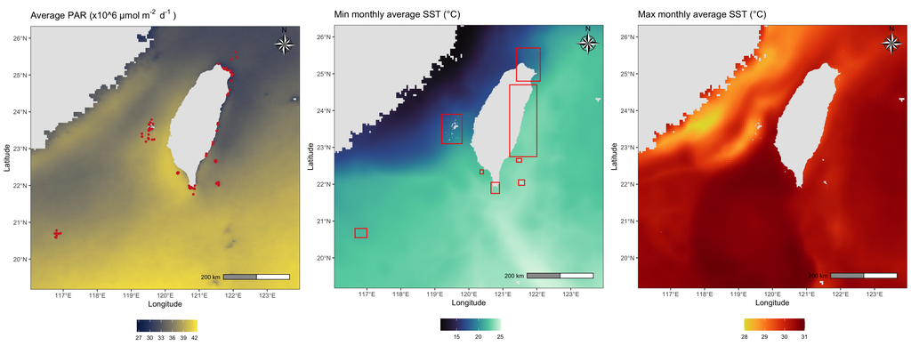

```r
# Arrange environmental maps together
ggpubr::ggarrange(PAR2, MinSST2, MaxSST2, ncol=3, nrow = 1)
```

### Benthic composition: regional differences and environmental effects

#### Regional benthic composition visualization

1. Import “Data summary - Regional Average Benthic Major Categories” and filter categories contributing at least 2.0% in at least one region (9 of 13 biotic and abiotic major categories)

```r
### Benthic patterns ###
# Regional summary
RegionalSummary<-read.csv("Data/Data summary - Regional Average Benthic Major Categories.csv")
RegionalSummary<-RegionalSummary[,c(1,3,5:7,9,11:14)]
RegionalSummary$Region <- as.factor(RegionalSummary$Region)
```

2. Calculate national average and pivot table to long format

```r
# National_average
National_avg <- colMeans(RegionalSummary[ , -1])

# Convert table to long format
RegionalSummary_long <- RegionalSummary %>%
  pivot_longer(
    cols = -Region,
    names_to = "major_category",
    values_to = "value")

# Turn the national_avg vector into a 2-column table
natavg_df <- data.frame(
  major_category = names(National_avg),
  national_avg   = as.numeric(National_avg)
)

# Attach the national averages
RegionalSummary_long <- RegionalSummary_long %>%
  left_join(natavg_df, by = "major_category")

# Round cover values
RegionalSummary_long$CoverRounded<-round((RegionalSummary_long$value*100), digits = 1)
RegionalSummary_long$NationalRounded<-round((RegionalSummary_long$national_avg*100), digits = 1)
```

3. Generate and arrange regional circular plots

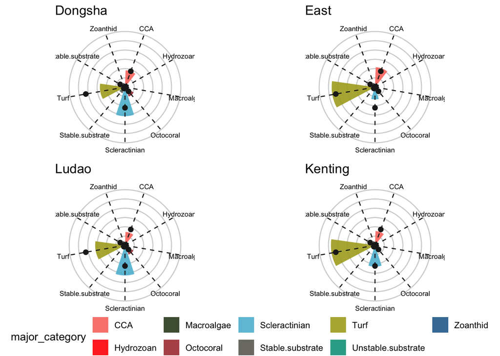

```r
# Define regions and their row ranges in data_long
regions <- list(
  "Dongsha"    = 1:9,
  "East"       = 10:18,
  "Ludao"      = 19:27,
  "Kenting"    = 28:36,
  "North"      = 37:45,
  "Lanyu"      = 46:54,
  "Penghu"     = 55:63,
  "Xiaoliuqiu" = 64:72
)

# Color palette
Palette<-c("#FA796C","#FF0000","#354823","#AC3E3F","#5BBCD6","#6C6A61","#ACA927","#00A08A","#296D9A")

# Single plotting function for circular plots
make_circular_plot <- function(RegionalSummary_long, region_name, show_legend = FALSE) {
  ggplot(RegionalSummary_long) +
    geom_hline(aes(yintercept = y), data.frame(y = c(0:6)*10), color = "lightgrey") +
    geom_col(
      aes(x = str_wrap(major_category, 5), y = CoverRounded, fill = major_category),
      position = "dodge2", show.legend = TRUE, alpha = .9
    ) +
    scale_fill_manual(values = Palette) +
    geom_point(
      aes(x = str_wrap(major_category, 5), y = NationalRounded),
      size = 2, color = "gray12"
    ) +
    geom_segment(
      aes(x = str_wrap(major_category, 5), y = 0,
          xend = str_wrap(major_category, 5), yend = 60),
      linetype = "dashed", color = "gray12"
    ) +
    coord_polar() +
    xlab("") +                        #removes x-axis label
    ylab("") +
    theme_void() +                    #removes grey background and axes
    theme(
      axis.text.x = element_text(size=7),   #keeps the category name labels around the circle
      legend.position = if (show_legend) "bottom" else "none"
        ) +
    ggtitle(region_name)
}

# Generate all plots in one loop
plots <- lapply(names(regions), function(name) {
  RegionalSummary_long <- RegionalSummary_long[regions[[name]], ]
  is_last <- name == tail(names(regions), 1)   # only last plot gets legend
  make_circular_plot(RegionalSummary_long, name, show_legend = FALSE)
})

# Arrange all together with legend below
# First 4 regions
ggpubr::ggarrange(
  plotlist = plots[1:4],
  ncol = 2, nrow = 2,
  common.legend = TRUE,
  legend = "bottom"
)
```

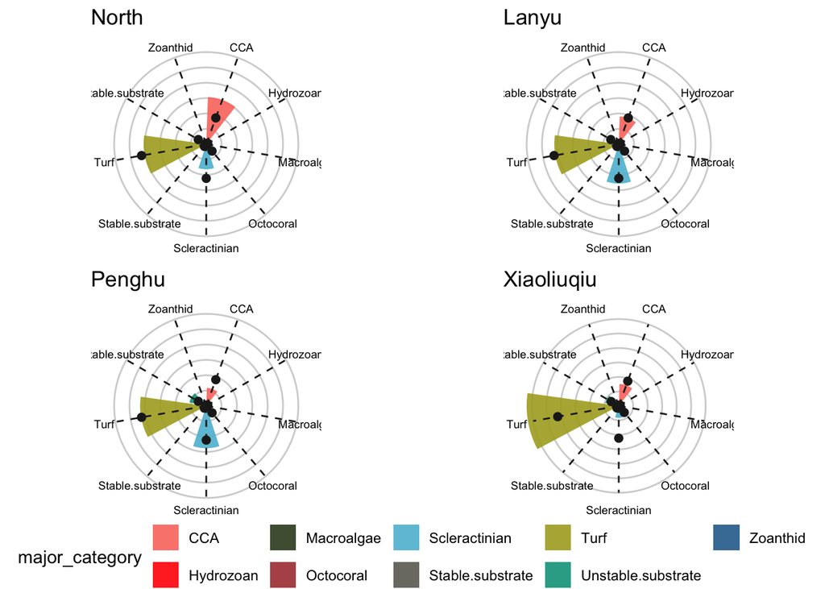

```r
# Last 4 regions
ggpubr::ggarrange(
  plotlist = plots[5:8],
  ncol = 2, nrow = 2,
  common.legend = TRUE,
  legend = "bottom"
)
```

#### Regional differences

1. Distance matrix, betadisper, permutest, tukey, PERMANOVA and boxplot (Figure 3A and B)

```r
### Regional differences ###
# Distance matrix
dis1<- vegdist(BenthicMorphoFunctnoEnvVar, method='bray')
mod<-betadisper (dis1,LocationFactor$Region) # multivariate homogeneity of groups dispersions on untransformed data (site Level)
permutest (mod, pairwise=T,permutations = 9999)
```

```
##
## Permutation test for homogeneity of multivariate dispersions
## Permutation: free
## Number of permutations: 9999
##
## Response: Distances
##            Df  Sum Sq  Mean Sq      F N.Perm Pr(>F)
## Groups      7 0.32087 0.045838 6.9768   9999  1e-04 ***
## Residuals 177 1.16291 0.006570
## ---
## Signif. codes:  0 '***' 0.001 '**' 0.01 '*' 0.05 '.' 0.1 ' ' 1
##
## Pairwise comparisons:
## (Observed p-value below diagonal, permuted p-value above diagonal)
##               Dongsha    Kenting      Lanyu Xiaoliuqiu      Ludao       East
## Dongsha               1.9100e-02 1.8000e-03 1.0000e-04 3.1800e-02 3.9500e-02
## Kenting    1.8511e-02            2.1370e-01 2.5000e-03 9.6010e-01 3.2950e-01
## Lanyu      1.5358e-03 2.1960e-01            4.8000e-02 2.5250e-01 1.9900e-02
## Xiaoliuqiu 3.4968e-05 3.1227e-03 5.0895e-02            4.7000e-03 2.0000e-04
## Ludao      3.1623e-02 9.6387e-01 2.5240e-01 5.4486e-03            3.9100e-01
## East       4.0781e-02 3.2314e-01 2.0879e-02 3.3546e-05 3.8104e-01
## Penghu     3.3617e-01 3.8053e-02 2.5199e-03 2.6627e-06 4.9124e-02 1.5270e-01
## North      8.1886e-04 6.1942e-01 3.0101e-01 8.6784e-04 5.9433e-01 6.3850e-02
##                Penghu  North
## Dongsha    3.4300e-01 0.0015
## Kenting    4.0500e-02 0.6192
## Lanyu      2.8000e-03 0.2989
## Xiaoliuqiu 1.0000e-04 0.0011
## Ludao      4.8400e-02 0.5853
## East       1.5970e-01 0.0629
## Penghu                0.0007
## North      8.9497e-04
```

```r
Tukey<-TukeyHSD(mod) # pairwise comparison

#Get superscript letter from Tukey HDS results assigned to each region
exp_lettersTUKEY <- multcompLetters(Tukey$group[,4])

#PERMANOVA
permanovaRegion<-adonis2(formula=BenthicMorphoFunctnoEnvVar~Region, data=LocationFactor, permutations=9999, method='bray') # Permutational Multivariate Analysis of Variance using bray-curtis distances
permanovaRegion
```

```
## Permutation test for adonis under reduced model
## Permutation: free
## Number of permutations: 9999
##
## adonis2(formula = BenthicMorphoFunctnoEnvVar ~ Region, data = LocationFactor, permutations = 9999, method = "bray")
##           Df SumOfSqs      R2      F Pr(>F)
## Model      7   3.6948 0.28899 10.277  1e-04 ***
## Residual 177   9.0904 0.71101
## Total    184  12.7852 1.00000
## ---
## Signif. codes:  0 '***' 0.001 '**' 0.01 '*' 0.05 '.' 0.1 ' ' 1
```

```r
#Pairwise PERMANOVA
set.seed(1)
pairwise.perm.manova(vegdist(BenthicMorphoFunctnoEnvVar,"bray", nperm = 999), LocationFactor$Region)
```

```
##
##  Pairwise comparisons using permutation MANOVAs on a distance matrix
##
## data:  vegdist(BenthicMorphoFunctnoEnvVar, "bray", nperm = 999) by LocationFactor$Region
## 999 permutations
##
##            Dongsha Kenting Lanyu  Xiaoliuqiu Ludao  East   Penghu
## Kenting    0.0012  -       -      -          -      -      -
## Lanyu      0.0043  0.0034  -      -          -      -      -
## Xiaoliuqiu 0.0012  0.0012  0.0012 -          -      -      -
## Ludao      0.0250  0.0012  0.0012 0.0012     -      -      -
## East       0.0012  0.0135  0.0023 0.0012     0.0012 -      -
## Penghu     0.0012  0.0012  0.0012 0.0012     0.0012 0.0012 -
## North      0.0012  0.0012  0.0012 0.0012     0.0012 0.0012 0.0012
##
## P value adjustment method: fdr
```

```r
# Create the boxplot with specified colors
BoxplotRegion<-boxplot(mod, col = c("#6C261C","#CC201B","#FB7069","#F69572","#F1BB7B","#50A45C","#354800","#296D9A"),
        names = c("Dongsha","Kenting", "Lanyu", "Xiaoliuqiu", "Ludao","East","Penghu","North"), xlab = "Region", las=2)
BoxplotRegion
```

```
## $stats
##           [,1]      [,2]       [,3]       [,4]      [,5]      [,6]      [,7]
## [1,] 0.1698502 0.1066853 0.08010104 0.06377600 0.1124350 0.1087298 0.1458390
## [2,] 0.2181916 0.1481379 0.14547235 0.08946547 0.1397957 0.1613506 0.1864794
## [3,] 0.2646574 0.1748715 0.16297406 0.10583965 0.1616578 0.2299856 0.2065294
## [4,] 0.3545132 0.2325289 0.19641481 0.13293593 0.2274231 0.2812656 0.2843200
## [5,] 0.5096458 0.2942301 0.25390023 0.19076071 0.3327142 0.3597054 0.4129570
##            [,8]
## [1,] 0.07731226
## [2,] 0.14117434
## [3,] 0.18703243
## [4,] 0.22390240
## [5,] 0.32186153
##
## $n
## [1]  8 19 15 20 20 27 33 43
##
## $conf
##           [,1]      [,2]      [,3]       [,4]      [,5]      [,6]      [,7]
## [1,] 0.1885062 0.1442817 0.1421919 0.09048159 0.1306991 0.1935229 0.1796191
## [2,] 0.3408085 0.2054613 0.1837563 0.12119771 0.1926165 0.2664483 0.2334397
##           [,8]
## [1,] 0.1670993
## [2,] 0.2069656
##
## $out
##          Houbihu_5m_20220410        Qixingyan_5m_20220412
##                   0.37374551                   0.37219111
##        Laurenyan_5m_20220712 Qingqingcaoyuan_10m_20190730
##                   0.06088912                   0.27380385
##    Zhongao_Beach_5m_20200610        Dabaisha_10m_20170103
##                   0.38918790                   0.43408445
##          Guiwan_10m_20170103           Gupoyu_5m_20210510
##                   0.42106440                   0.44072460
##       Huaientang_5m_20210508  Tiezhenyu_South_5m_20210509
##                   0.49324231                   0.46385649
##    Guishandao_1_10m_20200714          Pengjia_5m_20210816
##                   0.35076065                   0.35356884
##
## $group
##  [1] 2 2 3 3 4 5 5 7 7 7 8 8
##
## $names
## [1] "Dongsha"    "Kenting"    "Lanyu"      "Xiaoliuqiu" "Ludao"
## [6] "East"       "Penghu"     "North"
```

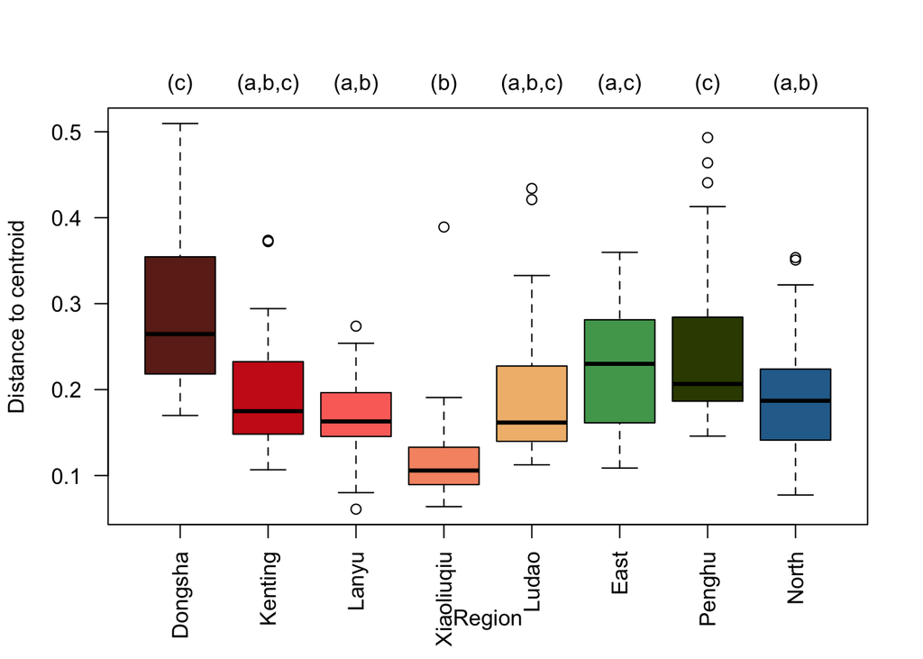

```r
# Add Tukey HSD letters above the boxplots
# Create a vector of superscript letters for each group
superscript_letters <- c("c", "a,b,c", "a,b", "b", "a,b,c", "a,c", "c", "a,b") #superscript letter order correspond to pairwise permutest results

# Add superscript letters above each boxplot
for (i in 1:length(custom_orderRegion)) {
  mtext(paste0("(", superscript_letters[i], ")"), side = 3, line = 0.5, at = i, adj = 0.5, cex = 1)
}
```

2. nMDS (Figure 3C)

```r
set.seed(1)
#require("latex2exp")
nmds1site <- metaMDS(BenthicMorphoFunctnoEnvVar, dist='bray', type='n', try=50)
```

```
## *** Best solution repeated 1 times
```

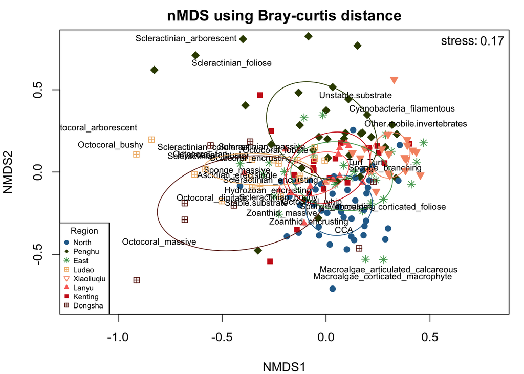

```r
par(mar = c(4, 4, 2, 1))  # fix margins
plot(0, main=bquote("nMDS using Bray-curtis distance"), xlim=c(-1.2,0.8), ylim=c(-0.8,0.8), xlab="NMDS1", ylab="NMDS2")

points(nmds1site, 'sites', pch=18, col="#354800",cex=1.5,select=LocationFactor$Region=='Penghu') # add transects from Penghu
points(nmds1site, 'sites', pch=8, col="#50A45C",select=LocationFactor$Region=='East')# add transects from Green Island
points(nmds1site, 'sites', pch=19, col="#296D9A",select=LocationFactor$Region=='North') # add transects from North Taiwan
points(nmds1site, 'sites', pch=15, col="#CC201B",select=LocationFactor$Region=='Kenting') # add transects from Kenting
points(nmds1site, 'sites', pch=25, bg="#F69572", col="#F69572",select=LocationFactor$Region=='Xiaoliuqiu')
points(nmds1site, 'sites', pch=17, col="#FB7069" ,select=LocationFactor$Region=='Lanyu')
points(nmds1site, 'sites', pch=12, col="#F1BB7B",select=LocationFactor$Region=='Ludao')
points(nmds1site, 'sites', pch=12, col="#6C261C",select=LocationFactor$Region=='Dongsha')

text(nmds1site, 'species', cex=0.7,) # visualize species names

#ordispider (nmds1site, LocationFactor$Region, col=c("#6C261C","#50A45C","#F1BB7B","#CC201B","#296D9A","#FB7069","#354800","#F69572")) # position centroids
ordiellipse(nmds1site, LocationFactor$Region, col=c("#6C261C","#CC201B","#FB7069","#F69572","#F1BB7B","#50A45C","#354800","#296D9A"))
text(x=0.8, y=0.8,c("stress:                   ",round(nmds1site$stress,2)))
# Add legend for regions
legend("bottomleft",
       legend = c("North", "Penghu", "East", "Ludao", "Xiaoliuqiu", "Lanyu", "Kenting", "Dongsha"),
       pch = c(19, 18, 8, 12, 25, 17, 15, 12),
       col = c("#296D9A","#354800","#50A45C","#F1BB7B","#F69572","#FB7069","#CC201B","#6C261C"),
       cex = 0.6,
       pt.cex = 0.7,
       title = "Region",
       title.cex = 0.7)
```

3. Dufrêne and Legendre indicator species analyses

```r
# Dufrêne and Legendre indicator species analyses on morpho-functional groups
IndMajCat<-indval(BenthicMorphoFunctnoEnvVar, LocationFactor$Region)

# Combine results into a dataframe
IndVal_results <- data.frame(
  species   = names(IndMajCat$maxcls),
  region    = IndMajCat$maxcls,        # assigned cluster/region
  indval    = IndMajCat$indcls,        # indicator value
  pval      = IndMajCat$pval           # significance
)

# Assign Region name to their corresponding cluster
IndVal_results$region_name <- levels(LocationFactor$Region)[IndVal_results$region]

# Filter significant indicative groups (p<0.05)
IndVal_sig <- IndVal_results[IndVal_results$pval < 0.05, ]

# Sort by region then by indval
IndVal_sig <- IndVal_sig[order(IndVal_sig$region, -IndVal_sig$indval), ]
print(IndVal_sig)
```

```
##                                                             species region
## Stable.substrate                                   Stable.substrate      1
## Octocoral_massive                                 Octocoral_massive      1
## Octocoral_digitate                               Octocoral_digitate      1
## Scleractinian_massive                         Scleractinian_massive      1
## Scleractinian_encrusting                   Scleractinian_encrusting      1
## Hydrozoan_bushy                                     Hydrozoan_bushy      2
## Scleractinian_columnar                       Scleractinian_columnar      3
## Sponge_encrusting                                 Sponge_encrusting      3
## Sponge_massive                                       Sponge_massive      3
## Octocoral_arborescent                         Octocoral_arborescent      3
## Other.mobile.invertebrates               Other.mobile.invertebrates      4
## Turf_Turf                                                 Turf_Turf      4
## Octocoral_clustered                             Octocoral_clustered      5
## Octocoral_bushy                                     Octocoral_bushy      5
## Octocoral_encrusting                           Octocoral_encrusting      5
## Macroalgae_Filamentous_Algae           Macroalgae_Filamentous_Algae      5
## Ascidian_erectsingle                           Ascidian_erectsingle      5
## Hydrozoan_arborescent                         Hydrozoan_arborescent      5
## Octocoral_fan                                         Octocoral_fan      5
## Hydrozoan_encrusting                           Hydrozoan_encrusting      6
## Scleractinian_arborescent                 Scleractinian_arborescent      7
## Scleractinian_foliose                         Scleractinian_foliose      7
## Unstable.substrate                               Unstable.substrate      7
## Zoanthid_massive                                   Zoanthid_massive      8
## Macroalgae_articulated_calcareous Macroalgae_articulated_calcareous      8
## Zoanthid_encrusting                             Zoanthid_encrusting      8
## CCA                                                             CCA      8
##                                      indval  pval region_name
## Stable.substrate                  0.4691942 0.001     Dongsha
## Octocoral_massive                 0.4523079 0.001     Dongsha
## Octocoral_digitate                0.3897054 0.015     Dongsha
## Scleractinian_massive             0.3122269 0.001     Dongsha
## Scleractinian_encrusting          0.1966298 0.006     Dongsha
## Hydrozoan_bushy                   0.3750058 0.004     Kenting
## Scleractinian_columnar            0.4901153 0.001       Lanyu
## Sponge_encrusting                 0.2916278 0.025       Lanyu
## Sponge_massive                    0.2333270 0.045       Lanyu
## Octocoral_arborescent             0.2235228 0.011       Lanyu
## Other.mobile.invertebrates        0.6005522 0.001  Xiaoliuqiu
## Turf_Turf                         0.1856467 0.001  Xiaoliuqiu
## Octocoral_clustered               0.7798005 0.001       Ludao
## Octocoral_bushy                   0.4571200 0.009       Ludao
## Octocoral_encrusting              0.3383942 0.030       Ludao
## Macroalgae_Filamentous_Algae      0.2390019 0.003       Ludao
## Ascidian_erectsingle              0.2056869 0.014       Ludao
## Hydrozoan_arborescent             0.1866024 0.036       Ludao
## Octocoral_fan                     0.1570586 0.018       Ludao
## Hydrozoan_encrusting              0.3193990 0.020        East
## Scleractinian_arborescent         0.6471238 0.001      Penghu
## Scleractinian_foliose             0.3667004 0.012      Penghu
## Unstable.substrate                0.2315805 0.039      Penghu
## Zoanthid_massive                  0.4076659 0.029       North
## Macroalgae_articulated_calcareous 0.3624681 0.005       North
## Zoanthid_encrusting               0.3431516 0.008       North
## CCA                               0.2115747 0.001       North
```

#### Environmental influence on benthic compositions

GAMs (Supplementary figure 2)

```r
### GAMs ###
# Selected env. parameters
# A. Latitude
fitLat<-ordisurf(nmds1site,BenthicMorphoFunctwithEnvVar$latitude, plot=FALSE)
summary(fitLat)
```

```
##
## Family: gaussian
## Link function: identity
##
## Formula:
## y ~ s(x1, x2, k = 10, bs = "tp", fx = FALSE)
##
## Parametric coefficients:
##             Estimate Std. Error t value Pr(>|t|)
## (Intercept)  23.2717     0.0815   285.5   <2e-16 ***
## ---
## Signif. codes:  0 '***' 0.001 '**' 0.01 '*' 0.05 '.' 0.1 ' ' 1
##
## Approximate significance of smooth terms:
##          edf Ref.df     F p-value
## s(x1,x2) 6.7      9 6.488  <2e-16 ***
## ---
## Signif. codes:  0 '***' 0.001 '**' 0.01 '*' 0.05 '.' 0.1 ' ' 1
##
## R-sq.(adj) =  0.241   Deviance explained = 26.9%
## -REML = 290.57  Scale est. = 1.2288    n = 185
```

```r
# B. PAR
fitPAR<-ordisurf(nmds1site,BenthicMorphoFunctwithEnvVar$PAR, plot=FALSE)
summary(fitPAR)
```

```
##
## Family: gaussian
## Link function: identity
##
## Formula:
## y ~ s(x1, x2, k = 10, bs = "tp", fx = FALSE)
##
## Parametric coefficients:
##             Estimate Std. Error t value Pr(>|t|)
## (Intercept)  34.8973     0.2242   155.6   <2e-16 ***
## ---
## Signif. codes:  0 '***' 0.001 '**' 0.01 '*' 0.05 '.' 0.1 ' ' 1
##
## Approximate significance of smooth terms:
##            edf Ref.df     F p-value
## s(x1,x2) 5.742      9 7.454  <2e-16 ***
## ---
## Signif. codes:  0 '***' 0.001 '**' 0.01 '*' 0.05 '.' 0.1 ' ' 1
##
## R-sq.(adj) =  0.267   Deviance explained =   29%
## -REML = 475.31  Scale est. = 9.3025    n = 185
```

```r
# C. Minimum monthly SST
fitTempMin<-ordisurf(nmds1site,BenthicMorphoFunctwithEnvVar$min.monthly.SST, plot=FALSE)
summary(fitTempMin)
```

```
##
## Family: gaussian
## Link function: identity
##
## Formula:
## y ~ s(x1, x2, k = 10, bs = "tp", fx = FALSE)
##
## Parametric coefficients:
##             Estimate Std. Error t value Pr(>|t|)
## (Intercept)   21.386      0.131   163.3   <2e-16 ***
## ---
## Signif. codes:  0 '***' 0.001 '**' 0.01 '*' 0.05 '.' 0.1 ' ' 1
##
## Approximate significance of smooth terms:
##            edf Ref.df     F  p-value
## s(x1,x2) 6.157      9 4.605 7.59e-07 ***
## ---
## Signif. codes:  0 '***' 0.001 '**' 0.01 '*' 0.05 '.' 0.1 ' ' 1
##
## R-sq.(adj) =  0.184   Deviance explained = 21.1%
## -REML = 377.34  Scale est. = 3.1733    n = 185
```

```r
# D. Maximum monthly SST
fitTempMax<-ordisurf(nmds1site,BenthicMorphoFunctwithEnvVar$max.monthly.SST, plot=FALSE)
summary(fitTempMax)
```

```
##
## Family: gaussian
## Link function: identity
##
## Formula:
## y ~ s(x1, x2, k = 10, bs = "tp", fx = FALSE)
##
## Parametric coefficients:
##             Estimate Std. Error t value Pr(>|t|)
## (Intercept) 29.87154    0.03697     808   <2e-16 ***
## ---
## Signif. codes:  0 '***' 0.001 '**' 0.01 '*' 0.05 '.' 0.1 ' ' 1
##
## Approximate significance of smooth terms:
##            edf Ref.df     F  p-value
## s(x1,x2) 6.526      9 4.489 1.12e-06 ***
## ---
## Signif. codes:  0 '***' 0.001 '**' 0.01 '*' 0.05 '.' 0.1 ' ' 1
##
## R-sq.(adj) =   0.18   Deviance explained = 20.9%
## -REML = 145.02  Scale est. = 0.25288   n = 185
```

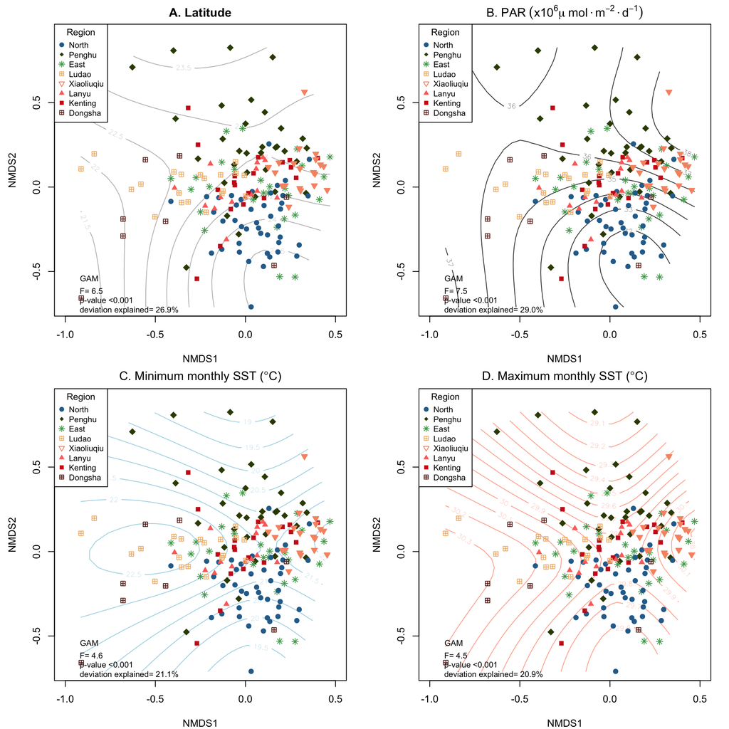

```r
par(mfrow=c(2,2), pty="s", mar=c(4,4,2,1))
# Plot GAMs onto the nMDS
# Extract nmds scores at the top of this chunk
scores_sites <- as.data.frame(vegan::scores(nmds1site, display="sites"))

# Define each GAM plot's parameters in a list
gam_plots <- list(
  list(var  = BenthicMorphoFunctwithEnvVar$latitude,
       col  = "grey",
       main = "A. Latitude",
       stat = c("F= 6.5", "p-value <0.001", "deviation explained= 26.9%")),
  list(var  = BenthicMorphoFunctwithEnvVar$PAR,
       col  = "grey25",
       main = bquote("B. PAR"~(x10^6*mu~mol%.%m^-2%.%d^-1)),
       stat = c("F= 7.5", "p-value <0.001", "deviation explained= 29.0%")),
  list(var  = BenthicMorphoFunctwithEnvVar$min.monthly.SST,
       col  = "lightblue",
       main = bquote("C. Minimum monthly SST ("*degree*"C)"),
       stat = c("F= 4.6", "p-value <0.001", "deviation explained= 21.1%")),
  list(var  = BenthicMorphoFunctwithEnvVar$max.monthly.SST,
       col  = "#ffb09c",
       main = bquote("D. Maximum monthly SST ("*degree*"C)"),
       stat = c("F= 4.5", "p-value <0.001", "deviation explained= 20.9%"))
)

# Single loop over the 4 plots
for (p in gam_plots) {
  plot(0, main=p$main, xlim=c(-1,0.5), ylim=c(-0.7,0.9), xlab="NMDS1", ylab="NMDS2")
  ordisurf(nmds1site, p$var, col=p$col, add=TRUE)
  legend(x=-1, y=-0.5,
       legend=p$stat,
       cex=0.8, bty="n", title="GAM", title.adj=0.15, adj=0,
       xpd=FALSE)
  points(scores_sites[LocationFactor$Region=='Penghu',],     pch=18, col="#354800", cex=1.5)
  points(scores_sites[LocationFactor$Region=='East',],       pch=8,  col="#50A45C")
  points(scores_sites[LocationFactor$Region=='North',],      pch=19, col="#296D9A")
  points(scores_sites[LocationFactor$Region=='Kenting',],    pch=15, col="#CC201B")
  points(scores_sites[LocationFactor$Region=='Xiaoliuqiu',], pch=25, col="#F69572", bg="#F69572")
  points(scores_sites[LocationFactor$Region=='Lanyu',],      pch=17, col="#FB7069")
  points(scores_sites[LocationFactor$Region=='Ludao',],      pch=12, col="#F1BB7B")
  points(scores_sites[LocationFactor$Region=='Dongsha',],    pch=12, col="#6C261C")
  legend("topleft",
         legend=c("North","Penghu","East","Ludao","Xiaoliuqiu","Lanyu","Kenting","Dongsha"),
         pch=c(19,18,8,12,25,17,15,12),
         col=c("#296D9A","#354800","#50A45C","#F1BB7B","#F69572","#FB7069","#CC201B","#6C261C"),
         cex=0.8, pt.cex=0.9, title="Region", title.cex=0.9)
}
```

```r
par(mfrow=c(1,1), pty="m")  # reset
```